# R Notebook: Examining student sessions

## Compute weekly session counts per student

Start by loading the data about learning actions during active course weeks (2-13); the data are loaded from the *Intermediate_results/trace_data_with_sessions_w2-13.RData* file.

```
'data.frame':   598201 obs. of  7 variables:
 $ USER_ID   : int  5 5 5 5 5 5 5 5 5 5 ...
 $ ACTION    : chr  "CONTENT_ACCESS" "VIDEO_PL" "CONTENT_ACCESS" "CONTENT_ACCESS" ...
 $ TIMESTAMP : POSIXlt, format: "2015-08-03 12:57:21" "2015-08-03 12:58:30" ...
 $ WEEK      : int  2 2 2 2 2 2 2 2 2 2 ...
 $ TOPIC     : chr  "COD" "COD" "COD" "CST" ...
 $ TIME_GAP  : num  NA 1.147 144.131 26.781 0.184 ...
 $ SESSION_ID: num  1 1 2 3 3 3 3 3 3 3 ...
```

The file contains data about 598201 learning actions in total, done by 371 students.

Next, compute the number of sessions per student and per week; create a matrix with students in the rows and weekly session counts in the columns.

The matrix with students’ weekly session counts (first few rows):

```
     [,1] [,2] [,3] [,4] [,5] [,6] [,7] [,8] [,9] [,10] [,11] [,12] [,13]
[1,]    5   13    7    4    7   28    3    3   11     1     8     2     3
[2,]    7   24   23   15   15   26    7   21   12    14    21    20     9
[3,]    9   31   21   20   18   27   10   11    7     9    16    14     5
[4,]   10    1    4    3   11   11    8    4    3    10     7     9    13
[5,]   11   10    9    8   10    9    4    4    2     5     2     2     1
[6,]   12   14    6    8   10   10    8    5    6     7     6     7     5
```

Transform the matrix into a data frame

```
'data.frame':   371 obs. of  13 variables:
 $ USER_ID: num  5 7 9 10 11 12 13 14 18 19 ...
 $ W2     : num  13 24 31 1 10 14 23 8 17 11 ...
 $ W3     : num  7 23 21 4 9 6 21 12 19 21 ...
 $ W4     : num  4 15 20 3 8 8 14 10 13 10 ...
 $ W5     : num  7 15 18 11 10 10 18 6 15 13 ...
 $ W6     : num  28 26 27 11 9 10 15 11 33 30 ...
 $ W7     : num  3 7 10 8 4 8 4 4 6 5 ...
 $ W8     : num  3 21 11 4 4 5 7 2 5 6 ...
 $ W9     : num  11 12 7 3 2 6 11 6 9 8 ...
 $ W10    : num  1 14 9 10 5 7 7 8 11 9 ...
 $ W11    : num  8 21 16 7 2 6 8 3 4 10 ...
 $ W12    : num  2 20 14 9 2 7 10 6 6 10 ...
 $ W13    : num  3 9 5 13 1 5 0 3 2 2 ...
```

Save the computed weekly counts to the file *Intermediate_results/weekly_per_student_session_counts.RData*

## Examine student profiles / groups based on the weekly session counts

The idea is to use the computed weekly session counts as the input for LCA or a clustering method to detect the presence of students with similar pattern of engagement during the course weeks

### Transform weekly session counts into multinomial variables

To use LCA, the weekly counts variables need to be transformed into multinomial variables. To that end, the counts variables will be dicretized, and turned into factor variables with 5 possible values:

- 0 - student had no sessions in the given week
- 1 - the student’s number of sessions belongs to the 1st quartile for the given week
- 2 - the student’s number of sessions belongs to the 2nd quartile for the given week
- 3 - the student’s number of sessions belongs to the 3rd quartile for the given week
- 4 - the student’s number of sessions belongs to the 4th quartile for the given week

Create a new data frame with multinomial variables as described above:

```
'data.frame':   371 obs. of  13 variables:
 $ USER_ID: num  5 7 9 10 11 12 13 14 18 19 ...
 $ W2     : Factor w/ 5 levels "0","1","2","3",..: 4 5 5 2 4 4 5 3 5 4 ...
 $ W3     : Factor w/ 5 levels "0","1","2","3",..: 3 5 5 2 3 2 5 4 5 5 ...
 $ W4     : Factor w/ 5 levels "0","1","2","3",..: 2 5 5 2 3 3 5 4 4 4 ...
 $ W5     : Factor w/ 5 levels "0","1","2","3",..: 3 4 5 4 3 3 5 3 4 4 ...
 $ W6     : Factor w/ 5 levels "0","1","2","3",..: 5 5 5 3 2 3 3 3 5 5 ...
 $ W7     : Factor w/ 5 levels "0","1","2","3",..: 2 5 5 5 3 5 3 3 4 4 ...
 $ W8     : Factor w/ 5 levels "0","1","2","3",..: 3 5 5 3 3 4 4 2 4 4 ...
 $ W9     : Factor w/ 5 levels "0","1","2","3",..: 5 5 4 3 2 4 5 4 5 4 ...
 $ W10    : Factor w/ 5 levels "0","1","2","3",..: 2 5 5 5 4 4 4 5 5 5 ...
 $ W11    : Factor w/ 5 levels "0","1","2","3",..: 5 5 5 4 2 4 5 3 3 5 ...
 $ W12    : Factor w/ 5 levels "0","1","2","3",..: 2 5 5 5 2 4 5 4 4 5 ...
 $ W13    : Factor w/ 5 levels "0","1","2","3",..: 3 5 4 5 2 4 1 3 3 3 ...
```

|  | USER_ID | W2 | W3 | W4 | W5 | W6 | W7 | W8 | W9 | W10 | W11 | W12 | W13 |
| --- | --- | --- | --- | --- | --- | --- | --- | --- | --- | --- | --- | --- | --- |
| 1 | 5 | 3 | 2 | 1 | 2 | 4 | 1 | 2 | 4 | 1 | 4 | 1 | 2 |
| 2 | 7 | 4 | 4 | 4 | 3 | 4 | 4 | 4 | 4 | 4 | 4 | 4 | 4 |
| 3 | 9 | 4 | 4 | 4 | 4 | 4 | 4 | 4 | 3 | 4 | 4 | 4 | 3 |
| 4 | 10 | 1 | 1 | 1 | 3 | 2 | 4 | 2 | 2 | 4 | 3 | 4 | 4 |
| 5 | 11 | 3 | 2 | 2 | 2 | 1 | 2 | 2 | 1 | 3 | 1 | 1 | 1 |
| 6 | 12 | 3 | 1 | 2 | 2 | 2 | 4 | 3 | 3 | 3 | 3 | 3 | 3 |

### Use LCA to group students based on the session distribution throughout the course

To determine the best value for the number of LCA classes, create models for different number of classes (2-7), and compute several statistical indicators (AIC, BIC, aBIC, cAIC) for each model

| nclass | AIC | BIC | ABIC | CAIC | LogLike | ChiSquare |
| --- | --- | --- | --- | --- | --- | --- |
| 2 | 11987.71 | 12367.59 | 12059.84 | 12464.59 | -5896.857 | 341297125549 |
| 3 | 11720.63 | 12292.40 | 11829.19 | 12438.40 | -5714.316 | 38181070683 |
| 4 | 11586.81 | 12350.47 | 11731.80 | 12545.47 | -5598.404 | 205586044 |
| 5 | 11543.31 | 12498.87 | 11724.73 | 12742.87 | -5527.657 | 164684224 |
| 6 | 11524.93 | 12672.37 | 11742.78 | 12965.37 | -5469.463 | 141926563 |
| 7 | 11549.47 | 12888.81 | 11803.75 | 13230.81 | -5432.733 | 113395673 |

#### Examine the model with 3 classes (BIC and cAIC drop and then rise again)

```
Conditional item response (column) probabilities,
 by outcome variable, for each class (row)

$W2
               0      1      2      3      4
class 1:  0.0656 0.4426 0.3614 0.0901 0.0403
class 2:  0.0094 0.0966 0.3523 0.3228 0.2189
class 3:  0.0123 0.0494 0.0327 0.2190 0.6866

$W3
               0      1      2      3      4
class 1:  0.0271 0.5444 0.3086 0.1198 0.0000
class 2:  0.0000 0.1601 0.2647 0.4076 0.1675
class 3:  0.0000 0.0000 0.0231 0.2504 0.7264

$W4
               0      1      2      3      4
class 1:  0.0475 0.5877 0.2145 0.1315 0.0188
class 2:  0.0000 0.1521 0.2410 0.3707 0.2362
class 3:  0.0000 0.0094 0.1121 0.2569 0.6217

$W5
               0      1      2      3      4
class 1:  0.0543 0.5110 0.3232 0.0650 0.0465
class 2:  0.0000 0.0691 0.4459 0.3742 0.1109
class 3:  0.0000 0.0106 0.0000 0.2730 0.7164

$W6
               0      1      2      3      4
class 1:  0.0339 0.4589 0.2090 0.1721 0.1260
class 2:  0.0000 0.1514 0.3609 0.2090 0.2788
class 3:  0.0000 0.0839 0.1829 0.3428 0.3904

$W7
               0      1      2      3      4
class 1:  0.0883 0.5333 0.1994 0.1208 0.0582
class 2:  0.0140 0.2618 0.1525 0.3321 0.2396
class 3:  0.0000 0.0636 0.1219 0.2209 0.5936

$W8
```

[output cut: 38 more lines]

```
Predicted class memberships (by modal posterior prob.)
 0.4016 0.3747 0.2237

=========================================================
Fit for 3 latent classes:
=========================================================
number of observations: 371
number of estimated parameters: 146
residual degrees of freedom: 225
maximum log-likelihood: -5714.316

AIC(3): 11720.63
BIC(3): 12292.4
G^2(3): 7044.356 (Likelihood ratio/deviance statistic)
X^2(3): 38180886141 (Chi-square goodness of fit)
```

Add the predicted class to each observation

Examine class counts and proportions

```
  1   2   3
149 139  83

    1     2     3
0.402 0.375 0.224
```

Save the features and the LCA class values to the file *results/LCA_based_on_weekly_session_counts.csv*

Plot the classes in the manner suggested in [this blog post](http://statistics.ohlsen-web.de/latent-class-analysis-polca/)

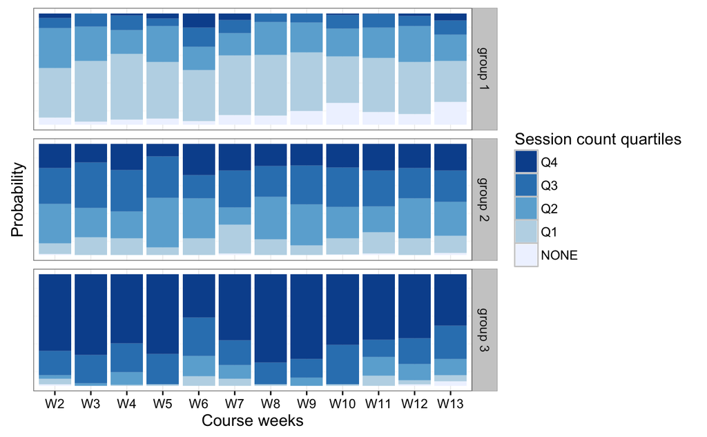

### Examine exam scores of students from different (LCA) groups

Load exam scores data and merge it with the identified LCA classes

```
'data.frame':   368 obs. of  4 variables:
 $ USER_ID  : num  5 7 9 10 11 12 13 14 18 19 ...
 $ LCA_CL   : Factor w/ 3 levels "1","2","3": 2 3 3 2 1 2 3 2 3 3 ...
 $ SC_MT_TOT: int  9 16 16 0 17 14 18 20 13 12 ...
 $ SC_FE_TOT: num  20 38 17.7 27 29.3 ...
```

Exam scores data are not available for all the students with learning actions data; in particular, 368 students have scores.

Compute the basic stats for the midterm and final exams

```r
mt.stats <- quantile(x = lca.and.scores$SC_MT_TOT, probs = c(0.25,0.5,0.75))
mt.stats
```

```
25% 50% 75%
 12  15  17
```

```r
fe.stats <- quantile(x = lca.and.scores$SC_FE_TOT, probs = c(0.25,0.5,0.75))
fe.stats
```

```
     25%      50%      75%
14.66667 20.50000 28.66667
```

#### Check if groups differ significantly w.r.t. the **midterm exam** score

Use [Kruskal-Wallis test](http://www.r-tutor.com/elementary-statistics/non-parametric-methods/kruskal-wallis-test) to check for significant difference among the groups

```
    Kruskal-Wallis rank sum test

data:  SC_MT_TOT by LCA_CL
Kruskal-Wallis chi-squared = 35.944, df = 2, p-value = 1.566e-08
```

Use [Mann-Whitney U Test](http://www.r-tutor.com/elementary-statistics/non-parametric-methods/mann-whitney-wilcoxon-test) to do pair-wise comparisons of LCA groups based on student midterm scores

|  | c1 | c2 | Z | p | r | significant | alpha |
| --- | --- | --- | --- | --- | --- | --- | --- |
| 2 | 1 | 3 | -5.7063 | 0.000000 | 0.3771 | YES | 0.0166667 |
| 1 | 1 | 2 | -3.8267 | 0.000118 | 0.2259 | YES | 0.0333333 |
| 3 | 2 | 3 | -2.6589 | 0.007662 | 0.1793 | YES | 0.0500000 |

#### Check if groups differ significantly w.r.t. the **final exam** score

Use Kruskal-Wallis test to check for the difference among the groups

```
    Kruskal-Wallis rank sum test

data:  SC_FE_TOT by class
Kruskal-Wallis chi-squared = 36.024, df = 2, p-value = 1.505e-08
```

Now, apply Mann-Whitney U Test to do pair-wise comparisons of the LCA groups

|  | c1 | c2 | Z | p | r | significant | alpha |
| --- | --- | --- | --- | --- | --- | --- | --- |
| 2 | 1 | 3 | -5.5155 | 0.000000 | 0.3645 | YES | 0.0166667 |
| 1 | 1 | 2 | -4.3867 | 0.000010 | 0.2589 | YES | 0.0333333 |
| 3 | 2 | 3 | -1.8493 | 0.064415 | 0.1247 | NO | 0.0500000 |

#### Examine more closely the students from the least active group (group 1) who have high scores

There are **33** students from the least active group with both midterm and final exam scores aboe the median values.

|  | USER_ID | W2 | W3 | W4 | W5 | W6 | W7 | W8 | W9 | W10 | W11 | W12 | W13 | SC_MT_TOT | SC_FE_TOT |
| --- | --- | --- | --- | --- | --- | --- | --- | --- | --- | --- | --- | --- | --- | --- | --- |
| 5 | 11 | 10 | 9 | 8 | 10 | 9 | 4 | 4 | 2 | 5 | 2 | 2 | 1 | 17 | 29.33 |
| 18 | 27 | 4 | 9 | 9 | 5 | 20 | 4 | 3 | 3 | 1 | 3 | 5 | 3 | 17 | 22.33 |
| 34 | 49 | 2 | 5 | 2 | 2 | 4 | 6 | 3 | 4 | 0 | 0 | 2 | 1 | 18 | 33.00 |
| 37 | 53 | 2 | 1 | 0 | 6 | 9 | 4 | 2 | 1 | 4 | 0 | 3 | 1 | 19 | 29.33 |
| 43 | 60 | 0 | 1 | 6 | 4 | 4 | 0 | 1 | 3 | 1 | 4 | 0 | 0 | 17 | 31.00 |
| 51 | 71 | 12 | 3 | 7 | 5 | 16 | 2 | 5 | 2 | 2 | 3 | 3 | 3 | 16 | 30.67 |
| 89 | 120 | 6 | 15 | 5 | 6 | 12 | 2 | 2 | 0 | 1 | 1 | 1 | 0 | 19 | 23.33 |
| 93 | 125 | 8 | 7 | 8 | 10 | 23 | 4 | 1 | 4 | 1 | 4 | 6 | 3 | 18 | 31.67 |
| 95 | 128 | 1 | 2 | 12 | 6 | 10 | 3 | 2 | 2 | 0 | 2 | 3 | 5 | 16 | 38.00 |
| 98 | 131 | 1 | 3 | 2 | 1 | 6 | 1 | 0 | 1 | 1 | 1 | 2 | 0 | 20 | 36.67 |
| 100 | 133 | 1 | 4 | 10 | 9 | 7 | 1 | 5 | 2 | 2 | 3 | 2 | 3 | 19 | 26.33 |
| 101 | 134 | 9 | 11 | 6 | 8 | 20 | 4 | 3 | 2 | 4 | 2 | 2 | 5 | 16 | 29.67 |
| 105 | 139 | 2 | 8 | 5 | 6 | 10 | 2 | 1 | 5 | 2 | 1 | 5 | 1 | 16 | 23.67 |
| 110 | 146 | 10 | 8 | 8 | 8 | 9 | 4 | 3 | 5 | 0 | 4 | 2 | 7 | 16 | 28.00 |
| 129 | 176 | 4 | 4 | 6 | 3 | 5 | 4 | 3 | 2 | 1 | 3 | 6 | 1 | 18 | 31.67 |
| 132 | 180 | 4 | 4 | 2 | 4 | 3 | 2 | 5 | 0 | 2 | 5 | 1 | 6 | 20 | 32.33 |
| 138 | 189 | 4 | 0 | 1 | 10 | 6 | 3 | 1 | 0 | 2 | 2 | 1 | 0 | 16 | 28.33 |
| 149 | 200 | 8 | 6 | 3 | 5 | 20 | 6 | 4 | 1 | 1 | 6 | 8 | 9 | 18 | 27.67 |
| 161 | 218 | 3 | 5 | 1 | 1 | 6 | 2 | 1 | 0 | 0 | 0 | 2 | 3 | 19 | 30.00 |
| 166 | 224 | 1 | 3 | 2 | 2 | 6 | 4 | 3 | 1 | 2 | 2 | 0 | 0 | 17 | 27.67 |
| 179 | 239 | 12 | 12 | 7 | 7 | 8 | 2 | 3 | 3 | 1 | 2 | 2 | 3 | 16 | 20.67 |
| 204 | 280 | 5 | 9 | 6 | 8 | 15 | 4 | 3 | 3 | 1 | 2 | 3 | 6 | 16 | 29.33 |
| 235 | 324 | 9 | 10 | 3 | 4 | 13 | 4 | 3 | 3 | 2 | 3 | 2 | 3 | 18 | 26.67 |
| 238 | 327 | 3 | 12 | 4 | 3 | 9 | 3 | 5 | 6 | 5 | 3 | 5 | 1 | 17 | 26.33 |
| 252 | 345 | 3 | 3 | 4 | 6 | 2 | 0 | 1 | 4 | 4 | 2 | 2 | 3 | 18 | 37.00 |
| 300 | 407 | 4 | 7 | 4 | 3 | 26 | 4 | 2 | 1 | 1 | 1 | 5 | 2 | 17 | 25.00 |
| 311 | 419 | 9 | 5 | 10 | 12 | 20 | 4 | 3 | 2 | 1 | 6 | 3 | 1 | 18 | 21.33 |
| 339 | 455 | 3 | 5 | 3 | 2 | 10 | 7 | 2 | 7 | 4 | 2 | 3 | 3 | 20 | 39.00 |
| 341 | 457 | 8 | 11 | 10 | 13 | 1 | 4 | 2 | 1 | 1 | 2 | 2 | 1 | 17 | 25.33 |
| 347 | 468 | 5 | 7 | 19 | 1 | 8 | 6 | 1 | 3 | 6 | 1 | 2 | 6 | 18 | 23.00 |
| 356 | 496 | 4 | 6 | 8 | 7 | 26 | 9 | 1 | 6 | 0 | 2 | 4 | 5 | 16 | 22.33 |
| 365 | 512 | 6 | 6 | 6 | 8 | 9 | 3 | 4 | 2 | 3 | 6 | 5 | 3 | 18 | 28.67 |
| 367 | 514 | 5 | 11 | 5 | 13 | 16 | 7 | 2 | 2 | 1 | 1 | 5 | 0 | 19 | 27.67 |